# Data Description:

# Analysis of Outliers

```python
Q1 = df.quantile(0.25)
Q3 = df.quantile(0.75)
IQR = Q3-Q1
outliers_lower =(Q1-(1.5*IQR))
outliers_upper = (Q3 +(1.5*IQR))
print('Number of lower outliers')
print(df[df<outliers_lower].count())
print('Number of upper outliers')
print(df[df>outliers_upper].count())
```

```
Number of lower outliers
cement          0
slag            0
ash             0
water           5
superplastic    0
coarseagg       0
fineagg         0
age             0
strength        0
dtype: int64
Number of upper outliers
cement           0
slag             2
ash              0
water            4
superplastic    10
coarseagg        0
fineagg          5
age             59
strength         4
dtype: int64
```

It can be seen that there is a significant amount of upper outliers in comparison to lower outlier. It can also be seen that there is a significant amount of upper outliers in the column age.This can be a flaw that might have happened in the sampling technique adopted for the experiment.I presume that procurement of older concrete samples were difficult in comparison to the procurement of newer samples.This might have resulted in the spike in the amount of new samples and a dearth in the number of older samples.This can also be seen in the long tail in the distribution for age.The replacement of these outliers with the median would lead to absence in the representation of older samples that are already few in number.

Apart from this,replacing the value of the outliers in the predicted variable 'strength' with median would not be a good idea as the purpose of this experiment would be find the correct ratio of constituents to produce the highest compressive strength of concrete and doing so seems to hamper the purpose of this experiment.

```python
for col in df.columns[:-1]: # leaving  the predicted variable strength
    q1 = df[col].quantile(0.25)
    q3 = df[col].quantile(0.75)
    iqr = q3 - q1

    outliers_lower = q1-1.5*iqr
    outliers_upper = q3+1.5*iqr

    df.loc[(df[col] < outliers_lower) | (df[col] > outliers_upper), col] = np.nan

print("The Number of outlier values replaced by NaN")
print(df.isna().sum())
print("Replacing all NaN values with the median of the corresponding column")
df.fillna(df.median(),inplace=True)
```

```
The Number of outlier values replaced by NaN
cement           0
slag             2
ash              0
water            9
superplastic    10
coarseagg        0
fineagg          5
age             59
strength         0
dtype: int64
Replacing all NaN values with the median of the corresponding column
```

```python
df.isna().sum()
```

```
cement          0
slag            0
ash             0
water           0
superplastic    0
coarseagg       0
fineagg         0
age             0
strength        0
dtype: int64
```

```python
#df.replace(0.0,np.nan,inplace = True)
```

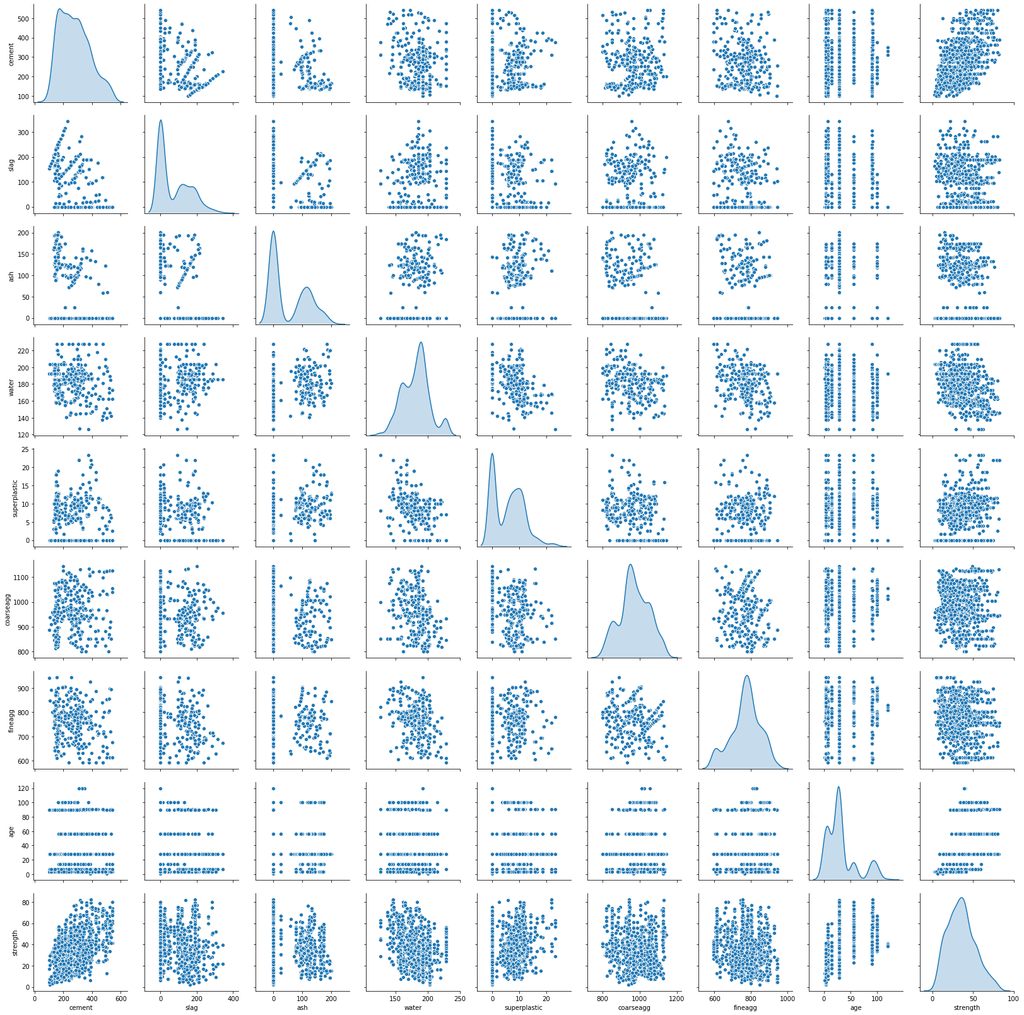

```python
import seaborn as sns

sns.pairplot(df,diag_kind='kde')
```

```python
df.corr()
```

|  | cement | slag | ash | water | superplastic | coarseagg | fineagg | age | strength |
| --- | --- | --- | --- | --- | --- | --- | --- | --- | --- |
| cement | 1.000000 | -0.275046 | -0.397467 | -0.091614 | 0.012407 | -0.109349 | -0.238710 | -0.031962 | 0.497832 |
| slag | -0.275046 | 1.000000 | -0.320468 | 0.098880 | 0.061272 | -0.283882 | -0.282386 | -0.028971 | 0.137800 |
| ash | -0.397467 | -0.320468 | 1.000000 | -0.248011 | 0.447878 | -0.009961 | 0.091740 | 0.057928 | -0.105755 |
| water | -0.091614 | 0.098880 | -0.248011 | 1.000000 | -0.657171 | -0.156928 | -0.426266 | -0.040304 | -0.307711 |
| superplastic | 0.012407 | 0.061272 | 0.447878 | -0.657171 | 1.000000 | -0.223819 | 0.156023 | 0.061938 | 0.345720 |
| coarseagg | -0.109349 | -0.283882 | -0.009961 | -0.156928 | -0.223819 | 1.000000 | -0.161358 | 0.018078 | -0.164935 |
| fineagg | -0.238710 | -0.282386 | 0.091740 | -0.426266 | 0.156023 | -0.161358 | 1.000000 | 0.051530 | -0.182197 |
| age | -0.031962 | -0.028971 | 0.057928 | -0.040304 | 0.061938 | 0.018078 | 0.051530 | 1.000000 | 0.499850 |
| strength | 0.497832 | 0.137800 | -0.105755 | -0.307711 | 0.345720 | -0.164935 | -0.182197 | 0.499850 | 1.000000 |

Concrete is a mixture of all the above mentioned constituents where the coarse aggregate forms the major matrix and the gaps in the major matrix are filled first by fine aggregate the matrix still has some gaps now which are filled by cement and hence concrete attains its tightly bound structure upon mixing with water and curing.

# 2. Deliverable -2 (Feature Engineering techniques)

a. Identify opportunities (if any) to create a composite feature, drop a feature

b. Decide on complexity of the model, should it be simple linear mode in terms of parameters or would a quadratic or higher degree help

c. Explore for gaussians. If data is likely to be a mix of gaussians, explore individual clusters and present your findings in terms of the independent attributes and their suitability to predict strength

```python
from scipy.stats import zscore
df_z = df.apply(zscore)
```

```python
df_z.head()
```

|  | cement | slag | ash | water | superplastic | coarseagg | fineagg | age | strength |
| --- | --- | --- | --- | --- | --- | --- | --- | --- | --- |
| 0 | -1.339017 | 1.625902 | -0.847144 | 1.060879 | -1.090749 | -0.014398 | -0.305664 | -0.153159 | -0.355018 |
| 1 | -1.074790 | -0.363717 | 1.096078 | -1.134020 | 0.882080 | 1.388141 | 0.300705 | -0.656933 | -0.737108 |
| 2 | -0.298384 | -0.858192 | 0.648965 | 0.279067 | -0.086067 | -0.206121 | 1.126995 | -0.153159 | -0.395144 |
| 3 | -0.145209 | 0.477594 | -0.847144 | 2.250592 | -1.090749 | -0.526517 | -1.303567 | -0.153159 | 0.600806 |
| 4 | -1.209776 | 1.290784 | -0.847144 | 0.565570 | 0.571542 | 0.958372 | -0.964153 | -0.153159 | -1.049727 |

```python
X_std = df_z.drop('strength',axis=1)
```

```python
y = df.pop("strength")
```

```python
covMatrix = np.cov(X_std,rowvar=False)
print(covMatrix)
```

```
[[ 1.00097182 -0.27531288 -0.39785361 -0.09170324  0.01241907 -0.10945526
  -0.23894166 -0.03199317]
 [-0.27531288  1.00097182 -0.32077961  0.0989759   0.06133185 -0.2841575
  -0.28266031 -0.02899893]
 [-0.39785361 -0.32077961  1.00097182 -0.24825152  0.44831367 -0.00997051
   0.0918287   0.05798414]
 [-0.09170324  0.0989759  -0.24825152  1.00097182 -0.65781002 -0.15708001
  -0.42668027 -0.04034284]
 [ 0.01241907  0.06133185  0.44831367 -0.65781002  1.00097182 -0.22403673
   0.15617487  0.06199855]
 [-0.10945526 -0.2841575  -0.00997051 -0.15708001 -0.22403673  1.00097182
  -0.16151498  0.01809514]
 [-0.23894166 -0.28266031  0.0918287  -0.42668027  0.15617487 -0.16151498
   1.00097182  0.05158035]
 [-0.03199317 -0.02899893  0.05798414 -0.04034284  0.06199855  0.01809514
   0.05158035  1.00097182]]
```

```python
from sklearn.decomposition import PCA
pca = PCA(n_components=7)
pca.fit(X_std)
```

```
PCA(copy=True, iterated_power='auto', n_components=7, random_state=None,
    svd_solver='auto', tol=0.0, whiten=False)
```

Eigen Values

```python
print(pca.explained_variance_)
```

```
[2.17063499 1.40571121 1.30037064 1.01503168 0.98826927 0.90797828
 0.17662395]
```

Eigen Vectors

```python
print(pca.components_)
```

```
[[ 0.13929891  0.20089837 -0.45535063  0.5417344  -0.52838215  0.0226363
  -0.38823078 -0.0948265 ]
 [-0.2949931   0.70408478 -0.00103802  0.06769707  0.28003653 -0.57505169
  -0.05466411 -0.02380444]
 [ 0.77006991 -0.00675333 -0.39206616 -0.28858325  0.26777114 -0.29965843
  -0.03077383 -0.0866428 ]
 [ 0.09583571  0.18669471  0.26618936 -0.12882614  0.32710765  0.39801173
  -0.77608023 -0.0281848 ]
 [ 0.07685001  0.041862   -0.07684633  0.03891784  0.00480729 -0.01680971
  -0.05583152  0.99070624]
 [ 0.19664632 -0.42095142  0.51266255  0.44539714  0.04716498 -0.52079789
  -0.22240364  0.00320338]
 [ 0.18310772  0.23939555  0.40321915 -0.50011928 -0.6755908  -0.18294413
  -0.07786906  0.02238913]]
```

```python
print(pca.explained_variance_ratio_)
```

```
[0.27106595 0.17554331 0.16238852 0.12675578 0.12341372 0.11338709
 0.02205656]
```

```python
np.cumsum(pca.explained_variance_ratio_)
```

```
array([0.27106595, 0.44660925, 0.60899777, 0.73575355, 0.85916727,
       0.97255436, 0.99461092])
```

We can see from the principle component analysis we have done that the first six component itself is needed to cover more than 95% variance of the data.So,using PCA for the purpose of reducing the number of variables seems to not help in consideration with the fact that the reduction in the number of components using PCA is just one.

A step plot depicting the same is given in the below.

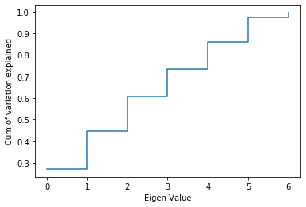

```python
plt.step(list(range(0,7)),np.cumsum(pca.explained_variance_ratio_), where='post')
plt.ylabel('Cum of variation explained')
plt.xlabel('Eigen Value')
plt.show()
```

b. Decide on complexity of the model, should it be simple linear mode in terms of parameters or would a quadratic or higher degree help

```python
# Splitting into train and test
from sklearn.model_selection import train_test_split
X_train, X_test, y_train, y_test = train_test_split(X_std, y, test_size = .30, random_state=0)
```

```python
# Import Linear Regression machine learning library
from sklearn.linear_model import LinearRegression
from sklearn.linear_model import Ridge
from sklearn.linear_model import Lasso
```

```python
regression_model = LinearRegression()
regression_model.fit(X_train, y_train)
```

```
LinearRegression(copy_X=True, fit_intercept=True, n_jobs=None, normalize=False)
```

```python
regression_model.coef_[1]
for idx,col_name in enumerate(X_train.columns):
   print("The coefficient for {} is {}".format(col_name, regression_model.coef_[idx]))
```

```
The coefficient for cement is 10.156464004845711
The coefficient for slag is 5.33098561401415
The coefficient for ash is 2.368372975579148
The coefficient for water is -3.563256119467301
The coefficient for superplastic is 1.4903890219768914
The coefficient for coarseagg is -0.6963659344422823
The coefficient for fineagg is -1.3703781737346388
The coefficient for age is 8.664872326460653
```

```python
intercept = regression_model.intercept_ # is the coefficient matrix a array why [0]
print("the intercept of our model is ",format(intercept))
```

```
the intercept of our model is  35.85260328610517
```

```python
regression_model.score(X_train, y_train)
```

```
0.7228304729322159
```

```python
regression_model.score(X_test, y_test)
```

```
0.6957432201303506
```

The linear regression model is not effective in predicting the strength of concrete.Hence we will have to rely on quadratic equations to better predcitions

Generating polynomial features

```python
from sklearn.preprocessing import PolynomialFeatures
```

```python
poly = PolynomialFeatures(degree = 2)
```

```python
X_poly = poly.fit_transform(X_std)
X_train, X_test, y_train, y_test = train_test_split(X_poly, y, test_size=0.30, random_state=1)
X_train.shape
```

```
(721, 45)
```

```python
regression_model.fit(X_train, y_train)
print(regression_model.coef_[0])
```

```
-1.0974339370894804e-16
```

```python
from sklearn.model_selection import GridSearchCV

lasso_params = {'alpha':[0.02, 0.024, 0.025, 0.026, 0.03]}
ridge_params = {'alpha':[200, 230, 250,265, 270, 275, 290, 300, 500]}
```

```python
ridge = Ridge()
grid_ridge = GridSearchCV( ridge , param_grid = ridge_params, cv = 10)
grid_ridge.fit( X_train, y_train)

print(" Best cross-validation accuracy: {:.2f}". format( grid_ridge.best_score_))
print(" Best parameters: ", grid_ridge.best_params_)
ridge.fit(X_train,y_train)
print ("Ridge model:", (ridge.coef_))
```

```
 Best cross-validation accuracy: 0.72
 Best parameters:  {'alpha': 200}
Ridge model: [ 0.         13.41965548  8.75098403  3.80557506 -2.65959585  1.09740063
  1.39536797  1.93705331 14.13647771  0.33595547  2.99187837  3.07567383
 -3.8207669  -2.87506428  2.33757628  0.56156497  1.06061839  1.44351138
  3.57594348 -0.88186267 -0.83589295  2.82079561  2.57592659  2.09478289
  1.73577411 -3.33266695 -3.55736104  2.36351752  1.81732209  1.57169592
 -1.08014892 -2.09566195 -2.81475845 -2.14984443  0.4863634  -1.71512691
 -1.75788277 -1.58808275  0.59394877  0.27177177  1.7161045   1.16161586
 -0.49590822  0.94049752 -4.65836884]
```

```python
grid_ridge.fit(X_train,y_train)
print(grid_ridge.score(X_train, y_train))
print(grid_ridge.score(X_test, y_test))
```

```
0.7603314272062696
0.7342925085211679
```

```python
lasso = Lasso()
grid_lasso = GridSearchCV( lasso , param_grid = lasso_params, cv = 10)
grid_lasso.fit( X_train, y_train)

print(" Best cross-validation accuracy: {:.2f}". format( grid_lasso.best_score_))
print(" Best parameters: ", grid_lasso.best_params_)
lasso.fit(X_train,y_train)
print ("Lasso model:", (lasso.coef_))
```

```
 Best cross-validation accuracy: 0.83
 Best parameters:  {'alpha': 0.03}
Lasso model: [ 0.          8.15070265  3.26258378  0.         -2.43619174  1.87653215
 -0.         -0.         10.62753217  0.          0.         -0.
 -0.         -0.         -0.         -0.         -0.         -0.
 -0.          0.          0.         -0.          0.          0.
  0.         -0.         -0.75904404  0.          0.          0.
  0.62128337  0.         -0.09985114 -0.         -0.         -0.34273579
  0.          0.          0.         -0.          0.          0.
 -0.         -0.         -2.58028189]
```

```python
grid_lasso.fit(X_train,y_train)
print(grid_lasso.score(X_train, y_train))
print(grid_lasso.score(X_test, y_test))
```

```
0.857776659045613
0.8338680856540616
```

The Lasso provides the better results in comparison to ridge in the regularisation methods

c. Explore for gaussians. If data is likely to be a mix of gaussians, explore individual clusters and present your findings in terms of the independent attributes and their suitability to predict strength

```python
from sklearn.cluster import KMeans
from scipy.stats import zscore
```

```python
cluster_range = range( 2, 12 )   # expect 3 to four clusters from the pair panel visual inspection hence restricting from 2 to 6
cluster_errors = []
for num_clusters in cluster_range:
  clusters = KMeans( num_clusters, n_init = 5)
  clusters.fit(df_z)
  labels = clusters.labels_
  centroids = clusters.cluster_centers_
  cluster_errors.append( clusters.inertia_ )
clusters_df = pd.DataFrame( { "num_clusters":cluster_range, "cluster_errors": cluster_errors } )
clusters_df[0:15]
```

|  | num_clusters | cluster_errors |
| --- | --- | --- |
| 0 | 2 | 7562.076559 |
| 1 | 3 | 6360.663127 |
| 2 | 4 | 5577.180185 |
| 3 | 5 | 5104.349285 |
| 4 | 6 | 4653.690628 |
| 5 | 7 | 4233.822951 |
| 6 | 8 | 3960.702406 |
| 7 | 9 | 3734.943197 |
| 8 | 10 | 3530.335103 |
| 9 | 11 | 3482.573843 |

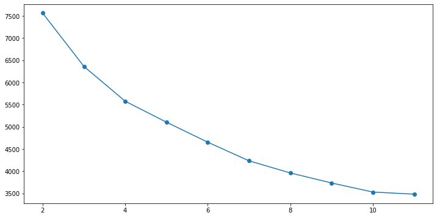

```python
# Elbow plot

plt.figure(figsize=(12,6))
plt.plot( clusters_df.num_clusters, clusters_df.cluster_errors, marker = "o" )
```

The elbow plot seems to be flatened out at n = 7.Hence,i am proceeding with n = 7 for my KMeans clustering

```python
cluster = KMeans( n_clusters = 7)
cluster.fit(df_z)

prediction=cluster.predict(df_z)
df_z["GROUP"] = prediction     # Creating a new column "GROUP" which will hold the cluster id of each record

#df_z_copy = df_z.copy(deep = True)  # Creating a mirror copy for later re-use instead of building repeatedly
```

[output not shown]

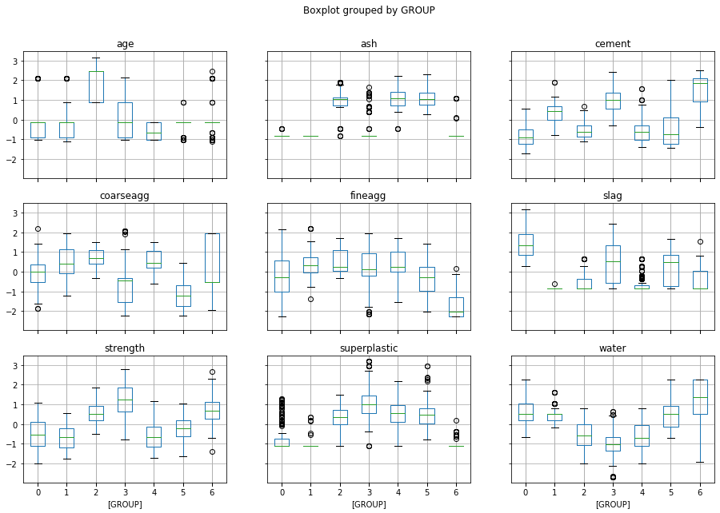

```python
df_z.boxplot(by = 'GROUP', figsize=(15, 10))
```

Inspite of the fact that we had seen a number of Guassians within the dataset during EDA.When K Means in order to form clusters it is seen that the clusters formed significantly overlap each other in most of the parameters.

# 3. Deliverable -3 (create the model )

a. Obtain feature importance for the individual features using multiple methods and present your findings

# 4. Deliverable -4 (Tuning the model)

a. Algorithms that you think will be suitable for this project b. Techniques employed to squeeze that extra performance out of the model without making it overfit or underfit c. Model performance range at 95% confidence level

```python
from sklearn.tree import DecisionTreeRegressor

dTree = DecisionTreeRegressor()
dTree.fit(X_train,y_train)
y_predict = dTree.predict(X_test)
print('\n')
print('Model Accuracy on Train Data :',dTree.score(X_train,y_train))
print('Model Accuracy on Test Data :',dTree.score(X_test,y_test))
```

```
Model Accuracy on Train Data : 0.9921715167957275
Model Accuracy on Test Data : 0.854742599045418
```

The descision tree is an overfit descision tree and hence pruning of the same is required

```python
print (pd.DataFrame(dTree.feature_importances_, columns = ["Imp"], index = X_train.columns))
```

[output not shown]

We can see that cement,water and age are most significant variables

```python
from sklearn.model_selection import GridSearchCV
from sklearn.svm import SVR

svr=SVR()
param_grid = {'C': [0.01, 0.05, 0.5, 1,2,5,10,20], 'kernel':['rbf','linear']}
grid_svr = GridSearchCV( svr, param_grid = param_grid, cv = 10)
grid_svr.fit( X_train, y_train)

print(" Best cross-validation accuracy: {:.2f}". format( grid_svr.best_score_))
print(" Best parameters: ", grid_svr.best_params_)

y_svr_predict = grid_svr.predict(X_test)
print(" Test set accuracy: {:.2f}". format( grid_svr.score( X_test, y_test)))
```

```
 Best cross-validation accuracy: 0.86
 Best parameters:  {'C': 20, 'kernel': 'rbf'}
 Test set accuracy: 0.87
```

The best test accuracy score obtained is 0.87 with C = 20 using Radial basis function kernel

```python
from sklearn.model_selection import GridSearchCV
from sklearn.ensemble import BaggingRegressor
from sklearn.neighbors import KNeighborsRegressor
from sklearn.tree import DecisionTreeRegressor


knn3 = KNeighborsRegressor(n_neighbors = 3)
knn5 = KNeighborsRegressor(n_neighbors = 5)
dTree3 = DecisionTreeRegressor(max_depth=3)
dTree5 = DecisionTreeRegressor(max_depth=5)

bgr = BaggingRegressor()



param_grid = {
    'base_estimator':[knn3,knn5,dTree3,dTree5],
    'max_samples': [0.5,1.0],
    'max_features': [0.5,1.0],
    'bootstrap': [True, False],
    'bootstrap_features': [True, False],
    'n_estimators': [10, 20, 30, 100]
}



# Instantiate the grid search model
grid_bgr = GridSearchCV(estimator = bgr, param_grid = param_grid, cv = 10)


grid_bgr.fit(X_train, y_train)

print(" Best cross-validation accuracy: {:.2f}". format( grid_bgr.best_score_))
print(" Best parameters: ", grid_bgr.best_params_)

y_bgr_predict = grid_bgr.predict(X_test)
print(" Test set accuracy: {:.2f}". format( grid_bgr.score( X_test, y_test)))
```

```
 Best cross-validation accuracy: 0.81
 Best parameters:  {'base_estimator': DecisionTreeRegressor(ccp_alpha=0.0, criterion='mse', max_depth=5,
                      max_features=None, max_leaf_nodes=None,
                      min_impurity_decrease=0.0, min_impurity_split=None,
                      min_samples_leaf=1, min_samples_split=2,
                      min_weight_fraction_leaf=0.0, presort='deprecated',
                      random_state=None, splitter='best'), 'bootstrap': True, 'bootstrap_features': False, 'max_features': 1.0, 'max_samples': 1.0, 'n_estimators': 30}
 Test set accuracy: 0.83
```

The test set accuracy is 0.83 by bagging using bootstrap aggregation of 30 decision tree regressor of maximum depth 5 estimators

```python
 from sklearn.model_selection import GridSearchCV
from sklearn.ensemble import AdaBoostRegressor
from sklearn.neighbors import KNeighborsRegressor
from sklearn.tree import DecisionTreeRegressor

abr = AdaBoostRegressor()

knn3 = KNeighborsRegressor(n_neighbors = 3)
knn5 = KNeighborsRegressor(n_neighbors = 5)
dTree3 = DecisionTreeRegressor(max_depth=3)
dTree5 = DecisionTreeRegressor(max_depth=5)


param_grid = {
    'base_estimator':[knn3,knn5,dTree3,dTree5],
    'loss': ['linear', 'square', 'exponential'],
    'learning_rate': [0.5, 0.1, 0.05],
    'n_estimators': [10, 20, 30, 100]
}

grid_abr = GridSearchCV(estimator = abr, param_grid = param_grid, cv = 10)

grid_abr.fit(X_train, y_train)

print(" Best cross-validation accuracy: {:.2f}". format( grid_abr.best_score_))
print(" Best parameters: ", grid_abr.best_params_)

y_abr_predict = grid_abr.predict(X_test)
print(" Test set accuracy: {:.2f}". format( grid_abr.score( X_test, y_test)))
```

```
 Best cross-validation accuracy: 0.85
 Best parameters:  {'base_estimator': DecisionTreeRegressor(ccp_alpha=0.0, criterion='mse', max_depth=5,
                      max_features=None, max_leaf_nodes=None,
                      min_impurity_decrease=0.0, min_impurity_split=None,
                      min_samples_leaf=1, min_samples_split=2,
                      min_weight_fraction_leaf=0.0, presort='deprecated',
                      random_state=None, splitter='best'), 'learning_rate': 0.5, 'loss': 'square', 'n_estimators': 100}
 Test set accuracy: 0.85
```

A test accuracy of 0.85 with AdaBoosting using the square loss function with a learning rate of 0.5 with 100 decision trees of maximum depth 5 using the mean square error as the creterion for regression.

```python
from sklearn.model_selection import GridSearchCV
from sklearn.ensemble import GradientBoostingRegressor
gbr = GradientBoostingRegressor()
param_grid = {

    'loss': ['ls', 'lad', 'huber'],
    'learning_rate': [0.5, 0.1, 0.05],
    'max_features': ['auto', 'sqrt','log2'],
    'min_samples_leaf': [3, 4, 5],
    'min_samples_split': [8, 10, 12],
    'n_estimators': [10, 20, 30, 100]
}


    # Instantiate the grid search model
grid_gbr = GridSearchCV(estimator = gbr, param_grid = param_grid, cv = 10)

grid_gbr.fit( X_train, y_train)

print(" Best cross-validation accuracy: {:.2f}". format( grid_gbr.best_score_))
print(" Best parameters: ", grid_gbr.best_params_)

y_gbr_predict = grid_gbr.predict(X_test)
print(" Test set accuracy: {:.2f}". format( grid_gbr.score( X_test, y_test)))
```

```
 Best cross-validation accuracy: 0.91
 Best parameters:  {'learning_rate': 0.5, 'loss': 'ls', 'max_features': 'log2', 'min_samples_leaf': 5, 'min_samples_split': 10, 'n_estimators': 100}
 Test set accuracy: 0.91
```

The test set accuracy of 0.91 with Grdient Boosting Regressor with a learning rate of 0.5 with 100 estimators using least squares loss function keeping maximum features in boosting aslgorithm as 'log2' of total features,minimum samples per leaf as 5 and minimum of samples per split as 10

```python
from sklearn.model_selection import GridSearchCV
from sklearn.ensemble import RandomForestRegressor
from sklearn import metrics

rf=RandomForestRegressor()

param_grid = {

    'bootstrap': [True],
    'max_depth': [4, 6, 8, 12, 16, 20],
    'max_features': ['auto', 'sqrt','log2'],
    'min_samples_leaf': [3, 4, 5],
    'min_samples_split': [8, 10, 12],
    'n_estimators': [10, 20, 30, 100]
}



# Instantiate the grid search model
grid_rf = GridSearchCV(estimator = rf, param_grid = param_grid, cv = 10)

grid_rf.fit( X_train, y_train)

print(" Best cross-validation accuracy: {:.2f}". format( grid_rf.best_score_))
print(" Best parameters: ", grid_rf.best_params_)
print(" Test set accuracy: {:.2f}". format( grid_rf.score( X_test, y_test)))
```

```
 Best cross-validation accuracy: 0.87
 Best parameters:  {'bootstrap': True, 'max_depth': 20, 'max_features': 'auto', 'min_samples_leaf': 3, 'min_samples_split': 8, 'n_estimators': 100}
 Test set accuracy: 0.88
```

It can be seen that gradient boosting regressor and the random forest regressor are the best performing models among all the models analysed hence we will have to evaluate the confidence intervals of these models before deployment for production.

```python
XY = X_std.join(y)
```

# For Bootstrap Random Forest

```python
from sklearn.ensemble import RandomForestRegressor
from sklearn.utils import resample
values = XY.values
# Number of bootstrap samples to create
n_iterations = 200
# size of a bootstrap sample
n_size = int(len(df_z) * 1)

# run bootstrap
# empty list that will hold the scores for each bootstrap iteration
stats = list()
for i in range(n_iterations):
    # prepare train and test sets
    train = resample(values, n_samples=n_size)  # Sampling with replacement
    test = np.array([x for x in values if x.tolist() not in train.tolist()])  # picking rest of the data not considered in sample


     # fit model
    rfTree = RandomForestRegressor(bootstrap= True, max_depth= 12, max_features= 'auto', min_samples_leaf= 3, min_samples_split= 8, n_estimators= 100)
    # fit against independent variables and corresponding target values
    rfTree.fit(train[:,:-1], train[:,-1])
    # Take the target column for all rows in test set

    y_test = test[:,-1]
    # evaluate model
    # predict based on independent variables in the test data
    score = rfTree.score(test[:, :-1] , y_test)
    predictions = rfTree.predict(test[:, :-1])

    stats.append(score)
```

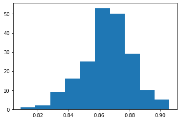

```
95.0 confidence interval 83.3% and 89.5%
```

```python
# plot scores

from matplotlib import pyplot
pyplot.hist(stats)
pyplot.show()
# confidence intervals
alpha = 0.95                             # for 95% confidence
p = ((1.0-alpha)/2.0) * 100              # tail regions on right and left 2.5 on each side indicated by P value (border)
lower = max(0.0, np.percentile(stats, p))
p = (alpha+((1.0-alpha)/2.0)) * 100
upper = min(1.0, np.percentile(stats, p))
print('%.1f confidence interval %.1f%% and %.1f%%' % (alpha*100, lower*100, upper*100))
```

The bootstrap random forest classification model performance is between 83.3%-89.5% in the 95% confidence interval.

# For Support Vector Regressor

```python
from sklearn.ensemble import GradientBoostingRegressor
from sklearn.utils import resample
values = XY.values
# Number of bootstrap samples to create
n_iteration = 200
# size of a bootstrap sample
n_size = int(len(df_z) * 1)

# run bootstrap
# empty list that will hold the scores for each bootstrap iteration
stats = list()
for i in range(n_iteration):
    # prepare train and test sets
    train = resample(values, n_samples=n_size)  # Sampling with replacement
    test = np.array([x for x in values if x.tolist() not in train.tolist()])  # picking rest of the data not considered in sample


     # fit model
    svr = SVR(C= 20, kernel= 'rbf')
    # fit against independent variables and corresponding target values
    svr.fit(train[:,:-1], train[:,-1])
    # Take the target column for all rows in test set

    y_test = test[:,-1]
    # evaluate model
    # predict based on independent variables in the test data
    score = svr.score(test[:, :-1] , y_test)
    predictions = svr.predict(test[:, :-1])

    stats.append(score)
```

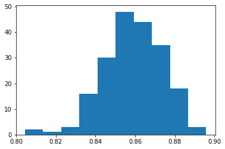

```
95.0 confidence interval 83.1% and 88.3%
```

```python
# plot scores

from matplotlib import pyplot
pyplot.hist(stats)
pyplot.show()
# confidence intervals
alpha = 0.95                             # for 95% confidence
p = ((1.0-alpha)/2.0) * 100              # tail regions on right and left 2.5 on each side indicated by P value (border)
lower = max(0.0, np.percentile(stats, p))
p = (alpha+((1.0-alpha)/2.0)) * 100
upper = min(1.0, np.percentile(stats, p))
print('%.1f confidence interval %.1f%% and %.1f%%' % (alpha*100, lower*100, upper*100))
```

The Support Vector Regressor achieves an accuracy of 83.1-88.3% in 95% confidence interval.

# For Gradient Boosting

```python
from sklearn.ensemble import GradientBoostingRegressor
from sklearn.utils import resample
values = XY.values
# Number of bootstrap samples to create
n_iteration = 200
# size of a bootstrap sample
n_size = int(len(df_z) * 1)

# run bootstrap
# empty list that will hold the scores for each bootstrap iteration
stats = list()
for i in range(n_iteration):
    # prepare train and test sets
    train = resample(values, n_samples=n_size)  # Sampling with replacement
    test = np.array([x for x in values if x.tolist() not in train.tolist()])  # picking rest of the data not considered in sample


     # fit model
    gbmTree = GradientBoostingRegressor(learning_rate= 0.5, loss= 'ls', max_features= 'log2', min_samples_leaf= 5, min_samples_split= 10, n_estimators= 100)
    # fit against independent variables and corresponding target values
    gbmTree.fit(train[:,:-1], train[:,-1])
    # Take the target column for all rows in test set

    y_test = test[:,-1]
    # evaluate model
    # predict based on independent variables in the test data
    score = gbmTree.score(test[:, :-1] , y_test)
    predictions = gbmTree.predict(test[:, :-1])

    stats.append(score)
```

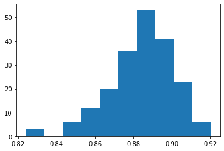

```
95.0 confidence interval 84.7% and 91.2%
```

```python
# plot scores

from matplotlib import pyplot
pyplot.hist(stats)
pyplot.show()
# confidence intervals
alpha = 0.95                             # for 95% confidence
p = ((1.0-alpha)/2.0) * 100              # tail regions on right and left .25 on each side indicated by P value (border)
lower = max(0.0, np.percentile(stats, p))
p = (alpha+((1.0-alpha)/2.0)) * 100
upper = min(1.0, np.percentile(stats, p))
print('%.1f confidence interval %.1f%% and %.1f%%' % (alpha*100, lower*100, upper*100))
```

The gradient boosting regressor achieves 84.7%- 91.2% accuracy in 95% confidence interval.This is the best performance given by any of the modelsand this model can be selected as the best suited machine learning model for this dataset